# Module 01: The R Workflow

Environment, Dependencies, and Data Foundations

## Agenda

| Block | Topic | Format |
| --- | --- | --- |
| 1 | Environment check | Interactive |
| 2 | How R works | Discussion + exploration |
| 3 | Packages and where they live | Hands-on |

**Steps completed:**

- R installed
- RStudio or Positron installed
- Git installed
- GitHub account created
- Quarto installed

## 1. Environment Check

Let’s verify everyone has a working setup.

### Is R installed?

```r
R.version.string
```

You should see something like `R version 4.x.x`.

**What is this actually telling us?** R is a program—a binary executable—installed somewhere on your computer. When you type `R` in a terminal or open RStudio, you’re launching that program.

### Where is R?

```r
# The R binary location
R.home()

# On Unix-like systems, you can also check from terminal:
# which R
```

### Is Git installed?

```r
system("git --version", intern = TRUE)
```

If this errors, Git isn’t installed or isn’t on your PATH.

### Is Quarto installed?

```r
system("quarto --version", intern = TRUE)
```

## 2. How R Works

If you’re using RStudio, you’ll see something like this:

[figure not shown]

The RStudio IDE

### R is an interpreter

When you type code at the console, R:

1. **Reads** your input
2. **Evaluates** it
3. **Prints** the result
4. **Loops** back waiting for more

This is called a **REPL** (Read-Eval-Print Loop).

```r
# Try this in your console:
2 + 2
```

[figure not shown]

The R console

There’s no compilation step. R interprets your code line by line.

### The R session

When R starts, it creates a **session**—a running instance of the R interpreter with:

- A **global environment** (where your objects live)
- A **working directory** (where R looks for files by default)
- Loaded **packages** (base R plus whatever you load)

```r
# Your current working directory
getwd()

# Your global environment (probably empty if you just started)
ls()

# What packages are currently loaded?
search()
```

### Everything is an object

In R, everything you create is an **object** stored in an environment:

```r
x <- 42
f <- function(a) a + 1

# Both are objects
class(x)
class(f)

# Both live in your global environment
ls()
```

The Environment pane shows all objects in your session:

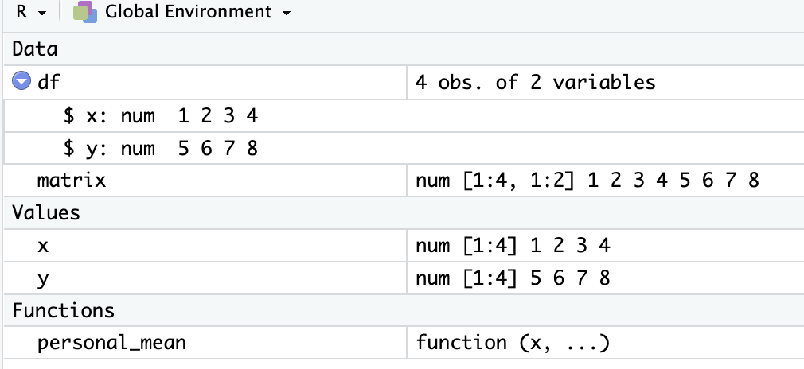

RStudio

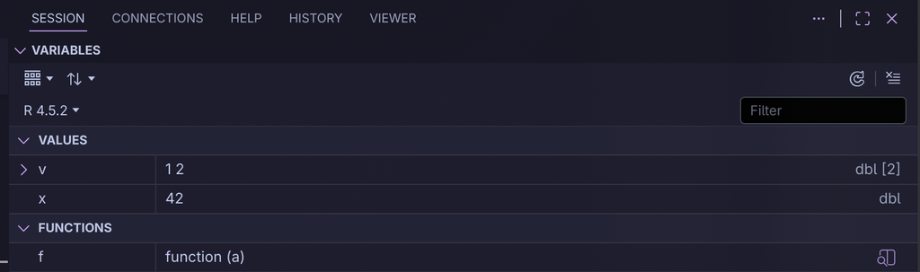

Positron

## 3. Packages and Where They Live

### What is a package?

A package is a bundle of:

- Functions
- Documentation
- Possibly data
- Metadata (who wrote it, what it depends on)

### Where do packages come from?

| Source | Examples | Install command |
| --- | --- | --- |
| CRAN | dplyr, ggplot2 | `install.packages("dplyr")` |
| Bioconductor | DESeq2, GenomicRanges | `BiocManager::install("DESeq2")` |
| GitHub | Most OHDSI/HADES packages | `remotes::install_github("OHDSI/CohortMethod")` |

### Where do packages live on your computer?

This is important to understand:

```r
# R searches these directories for packages, in order
.libPaths()
```

You’ll likely see:

1. A **user library** (packages you install)
2. A **system library** (packages that came with R)

### Let’s explore

```r
# Pick the first library path
lib_path <- .libPaths()[1]

# What's in there?
list.dirs(lib_path, recursive = FALSE) |> head(20)
```

Each subdirectory is an installed package. A package is literally just a folder with a specific structure.

### Installing a package

```r
# This downloads the package and puts it in your user library
install.packages("RSQLite")

# Now it exists on disk
file.exists(file.path(.libPaths()[1], "RSQLite"))
```

### Loading vs installing

**Installing** = downloading and saving to disk (do once)

**Loading** = making functions available in your session (do each session)

```r
# Load a package
library(RSQLite)

# Now its functions are available
# Check what's loaded
search()
```

## Wrap-up

Today we covered the foundations:

1. **R is a program**: a binary that interprets your code
2. **Sessions**: R runs in a session with an environment and working directory
3. **Objects**: everything in R is an object
4. **Packages are folders**: installed to library paths, loaded into sessions

Next module: Git, dependencies, and working with data.